# The Population Estimates Program

The number you get when nobody counted, and the arithmetic that produces it

Democracy’s Data

Last updated September 13, 2026 at 10:53a EDT

Almost every sentence that begins “the population of X is” is quoting neither of the two instruments in the last two chapters. The decennial census is ten years old the day after it is taken. The American Community Survey is a sample. Neither can tell you how many people live in a county *this year*.

The Population Estimates Program can, and it does it without asking anybody anything. It takes the last census and carries it forward with arithmetic. That makes it the third instrument, and the one people quote most while knowing least about. As the last chapter found, that includes anyone looking up an ACS county population, which is forced to agree with this program’s number.

It is also the quietest instrument to get wrong, because nothing in the file says which questions it can answer. This chapter opens the file and checks the arithmetic on every county in the country. It ends on the decision the whole section has been building to: when to quote a count, when a survey, and when an estimate.

## Where the data comes from, and what it is for

The program exists because the country will not hold still between censuses. The Constitution buys one count a decade; federal money, and nearly every published rate, moves every year. The estimates are the official bridge: the Bureau’s statement, for each year in between, of how many people live in every state, county and incorporated place.

**Who is in it, and how they got there.** Everyone the last census counted, plus and minus the changes the government’s own records can see. Nobody is asked anything. A person enters the estimates by appearing in a birth record and leaves by appearing in a death record — both reported through the vital-statistics system, the state registries that log every birth and death. Movers are seen indirectly, through administrative traces: address changes in federal records, mostly tax returns and Medicare enrollment, for moves inside the country, and a mix of records and survey data for moves across the border.[^1]

**Who it was made for.** The government’s own bookkeeping between counts. Funding formulas hand out money per person per year, and “per person” has to mean something in 2024, not 2020.[^2] The estimates are that something: the official **denominator** (the bottom number of a fraction, what you divide by) for birth rates, death rates, crime rates and every other per-capita figure quoted between censuses. They are also the **control totals**, the figures other Bureau products are required to match, which is why they reach further than their own tables.

**What it costs to get.** Nothing. The county file this chapter reads is a plain CSV, a spreadsheet-style text file, published by the Bureau at the address in the sources below: no key, no account.

**What has already been done to it.** Everything: an estimate is nothing but processing. The last census count, carried forward by addition and subtraction. The pieces adjusted so counties sum to their states and states to the nation. And a published **residual** (what is left over after you subtract) where the source systems disagree. The one thing that has *not* been done is asking anybody anything.

## How the Bureau publishes it

The program’s unit of publication is the **vintage**: not one new year of data, but the whole decade reissued. Each release carries a fresh estimate for *every* year since the last census, computed with that release’s best inputs. Vintage 2024 contains a 2021, a 2022 and a 2023; so did vintage 2023, and the two do not agree, because revised birth, death and migration records change the whole chain.

So there is no such thing as “the 2023 estimate”. There is the 2023 estimate of vintage 2023 and the 2023 estimate of vintage 2024, and citing one without its vintage is citing a book without its edition. The system is the program’s honesty about its own method — arithmetic can be re-run when an input improves, so the Bureau re-runs it annually rather than freezing old answers. The cost lands on the reader: a number you quoted last year has probably moved since, and a table built from two vintages mixes two versions of the past. This chapter reads one file, vintage 2024 (`co-est2024-alldata.csv`), and every figure in it is that vintage’s arithmetic.

The coverage runs from the nation down to states, counties, metropolitan areas, and cities and towns, released a level at a time through the year. Beside the totals sit **characteristics** files that break each total down by age, sex, race and Hispanic origin — and by nothing else. Income, education, language, occupation: none of it. The estimates answer *how many*, in four demographic dimensions, and stop.

One more absence is worth noticing before the worked example. There is no margin of error anywhere in the file — no statement of how far off a number could be. The ACS prints a stated uncertainty beside every freely estimated number; this program prints none, because there is no sample whose uncertainty could be stated. An estimate without a margin is not a number without error. It is a number whose error nobody measured.

## The worked example: one vintage, checked and decomposed

This year’s population is last year’s, plus the people born, minus the people who died, plus the people who moved in, minus the people who moved out.

That is not a simplification of the method. That *is* the method, and every term in it is published. Which means the claim is checkable — so here it is, checked on every county in the country:

| Consistency check | Counties checked | Violations |
| --- | --- | --- |
| Last year + natural change + net migration + residual = this year | 3,144 | 0 |
| International + domestic migration = net migration | 3,144 | 0 |
| Births - deaths = natural change | 3,144 | 0 |

**Zero violations in 3,144 counties.** Every published estimate is exactly the sum of the published components beneath it.

That is worth doing rather than believing, because of what it establishes about the object. A census figure is the result of an attempt to find people. An ACS figure is the result of asking some of them. **A population estimate is the result of an addition** — and if any input to that addition is wrong, the total is wrong in a way no amount of staring at the total will reveal.

### What arrives

```
One row of the file: DeKalb County, Georgia.
The file is 1.8 MB of plain CSV and every county carries the same
columns. These are the ten that make up one year's arithmetic:

  POPESTIMATE2023             768,047
  BIRTHS2024                   10,016
  DEATHS2024                    5,200
  NATURALCHG2024                4,816
  INTERNATIONALMIG2024          8,755
  DOMESTICMIG2024             -11,219
  NETMIG2024                   -2,464
  RESIDUAL2024                    -92
  NPOPCHG2024                   2,260
  POPESTIMATE2024             770,307

Read down: last year's estimate, then births and deaths and the
difference between them, then the two halves of migration and their
sum, then the residual, then the total change, then this year's
estimate. The last line is the sum of everything above it.

STATE and COUNTY are zero-padded FIPS codes and must be read as
text. As numbers they lose their leading zeros and stop joining to
anything else in this book.
```

### What the components said in 2024

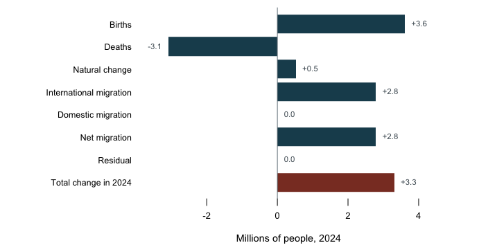

**Figure 1. The components of change in 2024, summed over all 3,144 counties.** Each bar is one term of the estimate’s arithmetic, in millions of people: bars pointing right added people, bars pointing left removed them, and the darker bar is the total they sum to. A bar chart fits this because an estimate *is* a sum — the addends are the figure’s whole content, and length against a shared zero line shows at a glance which terms carry the total. Notice the two rows with no bar at all: domestic migration and the residual both net to exactly zero across the country, for reasons the next paragraphs take up.

Two rows deserve a second look.

**Domestic migration is exactly zero.** Not approximately — exactly. That is not a finding about America, it is arithmetic: every person who leaves one county arrives in another, so internal movement nets to nothing nationally. Domestic migration redistributes the population and adds none of it. It is the single largest force reshaping individual counties and it is invisible at the national level.

**International migration is 2,786,119 of 3,304,757.** That is **84.3% of all United States population growth in 2024**, against 518,638 from births exceeding deaths. The country grew mostly because people arrived, not because more were born than died.

### Two-thirds of counties had more deaths than births

| Quantity | Value |
| --- | --- |
| Counties with more deaths than births, 2024 | 2,076 |
| Share of all counties | 66.0% |
| People living in those counties | 97,700,142 |
| Share of the country living in them | 28.7% |

**2,076 counties recorded more deaths than births in 2024**, or 66.0% of them. Natural decrease is not a rare condition of a few dying places. It is the ordinary state of two-thirds of American counties.

Those counties hold only 28.7% of the population. That is the other half of the same fact. The counties where deaths outnumber births are mostly small ones, and the country’s people are concentrated in the minority that still has more births.

| Quantity | Counties |
| --- | --- |
| Counties that grew in 2024 | 2,054 |
| Of those, would have shrunk without international migration | 451 |
| Of those, would have shrunk without natural change | 91 |
| Counties that grew despite more deaths than births | 1,160 |

Read those together. 2,054 counties grew. **1,160 of them grew while burying more people than they delivered** — migration made up the difference. And 451 of the counties that grew **would have shrunk without international migration specifically**.

That last figure is subtraction, not modeling: a county’s published total change, minus its published international migration. Nothing is re-estimated. It says what the file says.

### The part that does not add up

The equation above, what an accountant would call an identity, a sum that must balance by definition, has a term this chapter has not yet explained. Alongside births, deaths and migration, the Bureau publishes a column called **residual** — what is left over, the part of the change the components do not account for.

| Quantity | Value |
| --- | --- |
| Counties with a residual of zero | 663 |
| Counties with a non-zero residual | 2,481 |
| Largest residual, in people | 247 |
| Total residual, all counties | 0 |
| Total residual as a share of total change | 0.0% |

2,481 of 3,144 counties carry one, and the largest is 247 people. But look at the total: **the residual sums to 0 across the whole country.** It is constrained to net out. It moves people between counties to make each county’s arithmetic close, and adds none to the national total.

That should sound familiar. It is the same shape as the disclosure-avoidance noise in the source chapter, the deliberate blur the Bureau adds to small-area census counts to protect privacy: an adjustment that is real at the bottom of the hierarchy and vanishes at the top, held there by construction. The difference is that this one is printed in its own column, and you can read it.

A residual is not a scandal. It is what an accounting identity does when the components come from different administrative systems that do not perfectly agree. It is published rather than absorbed silently into migration, which is the honest choice. But it is a plug, and it is worth knowing that the tidiest of the three instruments has one.

## When to use it, and when to use something else

The estimates are not an alternative that careful people avoid. They are *inside* the data most people use.

When you look up a county’s population in the ACS, the number you get was **controlled** to this program: the survey was not allowed to disagree with it. That is why 3,090 of 3,222 ACS county rows print no margin of error, no statement of how far off the estimate could be, as the ACS chapter found. The estimate is doing work in places that do not announce it.

So the three instruments are not three independent readings you can average or choose between. The decennial anchors the estimates; the estimates control the survey. A problem in the census propagates forward into both — an error in the 2020 count does not fade as the decade passes, it is carried faithfully into every estimate built on top of it.

Which leaves the decision this section has been circling since its first page. **Reach for the decennial census when the question is a moment or a legal count**: how many people lived somewhere on 1 April 2020, apportionment, district lines, anything a court will read. **Reach for the ACS when the question is about characteristics**: income, language, education, commuting (anything the count never asked), and take the margin of error along with the answer. **Reach for the estimates when the question is how many people live somewhere *this year***: a current total, or the denominator under this year’s rate. Ask all three about one county and you will get three different numbers, none wrong, each answering its own question. The skill is naming which one your sentence needs.

## What this data cannot tell you

**One vintage, one year.** Everything here is the 2024 vintage, describing change in 2024. The Bureau reissues the whole series every year, and a reissued vintage revises earlier years — so a “2023 population” from this file and a “2023 population” from last year’s file are different numbers. This chapter does not measure that drift; it is the most important thing about estimates that it leaves out.

**Nothing about anybody beyond age, sex, race and Hispanic origin.** The totals file this chapter reads carries no characteristics at all, and the program’s characteristics files stop at those four dimensions. Ask an estimate about income, language or education and it has nothing to say. That is the ACS’s job, and the division of labour is deliberate.

**The components are not measured here, only used.** Births and deaths come to the Bureau from vital-statistics systems, and migration from a mix of administrative records and survey data. This chapter checks that the published components sum to the published totals. It cannot check whether any component is right, and the identity holding tells you nothing about that — a sum of wrong numbers adds up perfectly well.

**Counties are as far down as this goes.** The program publishes estimates for places below the county level too, and the smaller the place the more the estimate depends on assumptions rather than on records. The file states no margin of error at any level, so how much to trust a small place’s figure is a judgement the data does not help you make.

**“Would have shrunk without international migration” is not a forecast.** It subtracts one published component from one published total for one year. It is not a claim about what people would have done had they not moved, or about any future year.

## What you should have learned

- A population estimate is arithmetic, not measurement: last year’s population, plus births, minus deaths, plus and minus movers — an identity that holds with 0 violations across all 3,144 counties.
- In 2024 the United States grew by 3,304,757 people, and 84.3% of that growth was international migration, against 518,638 people from births exceeding deaths.
- Natural decrease is ordinary: 2,076 counties — 66.0% of them — recorded more deaths than births, and 1,160 of those still grew because people moved in.
- A vintage reissues and revises the whole decade behind it, so an estimate is not fully named until its vintage is named.
- The estimates carry no margin of error and no characteristics beyond age, sex, race and Hispanic origin: they answer *how many, this year*, and hand every other question to the census or the ACS.

## Where this data appears in this book

This cluster is still growing: the estimates have no briefs of their own yet. But the program’s numbers already surface elsewhere in this section, mostly without announcing themselves:

- The American Community Survey — the chapter before this one, where 3,090 of 3,222 county population rows print no margin because they were controlled to this program’s figures.
- How Many People Live in Allegheny County? — the brief that finds a county’s one-year ACS total to be this file’s estimate exactly, to the person.

And whenever a later chapter divides something by “the population” of a between-census year, the denominator is usually an estimate — so this chapter’s caution about vintages travels further than its own cluster.

## Sources

- U.S. Census Bureau. *Population Estimates Program*, county totals with components of change, vintage 2024 (`co-est2024-alldata.csv`). https://www2.census.gov/programs-surveys/popest/datasets/2020-2024/counties/totals/
- U.S. Census Bureau. *Population Estimates: Technical Documentation and Methodology* — the Bureau’s own statement of where the births, deaths and migration components come from and how the series is revised by vintage. https://www.census.gov/programs-surveys/popest/technical-documentation/methodology.html
- The `-555555555` sentinel that marks a controlled estimate is in the ACS chapter. The control relationship itself is measured in the access chapter, which finds a county’s one-year survey total to be this file’s estimate exactly.

**The data itself**

Every figure above is drawn from these tables. They are plain CSV, they open in a spreadsheet, and they are yours to take further.

`components.csv`, `growth.csv`, `identity.csv`, `natural.csv`, `residual.csv`, `controlled.csv`

**Your turn**

None of these is answered above, and every one can be answered from the tables you just opened.

- `identity.csv` records, in its `violations` column, that the accounting identity holds in every county with no violations at all. A check that cannot fail teaches nothing. Work out what would have to go wrong in the world for that column to stop reading zero.
- `residual.csv` counts, in its `value` column, the counties whose residual is exactly zero. The residual is the part the arithmetic could not explain. Does a zero mean nothing was unexplained, or that nothing was measured?
- `natural.csv` says most counties buried more people than they delivered. `growth.csv` counts the counties that grew anyway. Hold the two `value` columns side by side and explain how both can be true.
- `components.csv` gives, in its `people` column, the national totals going into the estimate. Which component is largest, and which one can the Bureau least afford to get wrong?

Rebuild this data yourself, with an AI assistant

```
I want to rebuild a public dataset from its original source, without any
starting files. Please do the following and show your work.

THE SOURCE. U.S. Census Bureau, Population Estimates Program, county
totals with components of change, vintage 2024. One CSV, about 1.8 MB,
published at
https://www2.census.gov/programs-surveys/popest/datasets/2020-2024/counties/totals/co-est2024-alldata.csv
No account or key is needed. Each row is a state or county; the SUMLEV
column says which (040 is a state, 050 is a county). Read the STATE and
COUNTY columns as text, not numbers — they are zero-padded codes, and
"01" stops being Alabama the moment it becomes 1.

WHAT TO BUILD.
1. Check the Bureau's own accounting identity on every county: the 2023
   estimate, plus births minus deaths, plus net migration, plus the
   column called RESIDUAL, should equal the 2024 estimate exactly.
   Report how many counties pass and how many fail.
2. Count the counties where deaths exceeded births in 2024, and what
   share of all counties that is.

CHECK YOUR WORK. The copy this book used was downloaded in August 2026.
If your rebuild matches it, you should find:
- 3,195 rows in the file: 51 state rows and 3,144 county rows
- the identity holds on all 3,144 counties, with zero violations
- 2,076 counties had more deaths than births in 2024 — 66% of them
The Bureau replaces this file when a new vintage comes out each spring;
if the URL now says a later year, the numbers will differ because the
estimates were revised, not because you made an error.
```

[^1]: The Bureau’s own account of where each component comes from is its methodology statement for the estimates: https://www.census.gov/programs-surveys/popest/technical-documentation/methodology.html.
[^2]: Marisa Hotchkiss and Jessica Phelan, “Uses of Census Bureau Data in Federal Funds Distribution,” U.S. Census Bureau working paper (2017), which traces the programs whose formulas depend on these figures: https://www.census.gov/library/working-papers/2017/decennial/census-data-federal-funds.html.